# Practical Data Science: Analyzing Stock Market Data with R

*Insight from a Moving Average*

In this lecture we’ll look at: * Very brief introduction to technical analysis * Creating a moving average from scratch * Overlaying a simple moving average (SMA) over a chart

**Very brief introduction to technical analysis**

There are many tools out there to analyze the markets. There’s a spectrum with [fundamental analysis](https://en.wikipedia.org/wiki/Fundamental_analysis) on one end to [quantitative analysis](https://en.wikipedia.org/wiki/Quantitative_analyst) on the other. All are loaded terms; one uses things like earnings, market cap, etc, while the other is mathematical, created by PhD’s correlating many things together and jumping in and out of the market in a matter of seconds. Somewhere in between is [technical analysis](https://en.wikipedia.org/wiki/Technical_analysis), also a loaded term, that uses patterns and market behavior to forecast moves. We’re mostly going to limit our exploration to a handful of technical analysis indicators that we can tie to charts and market data.

We’ll start with the **moving average**, **the grand-daddy of all indicators**. It forms the basis of some many other indicators.

So, what’s a technical indicator? Usually some equation deriving raw market movement into a simplified form and laid upon a chart. And that is what we’re going to do, create a moving average of raw market data and display it. The moving average, as you can imagine, is used to smooth out the crazy gyrations and whipsaws we see on raw charts. And it is moving because if we took an entire average of a market, it wouldn’t do us much good, just a straight line. Instead, we make it move by taking the current point and averaging x numbers of points backwards. This creates a slower and calmer line forming a simplified shape of the raw market data.

**A Moving Average From Scratch**

Even though the **TTR** package offers a slew of moving averages (and yes, there are many different ones), we’re going to do one from scratch to understand how it works. Let’s start by getting some data:

```r
library(quantmod)
getSymbols(c('QQQ'), src='google')
```

We’ll focus on the Close of the bar (where it closed for the day). Let’s take a quick peek at what we have:

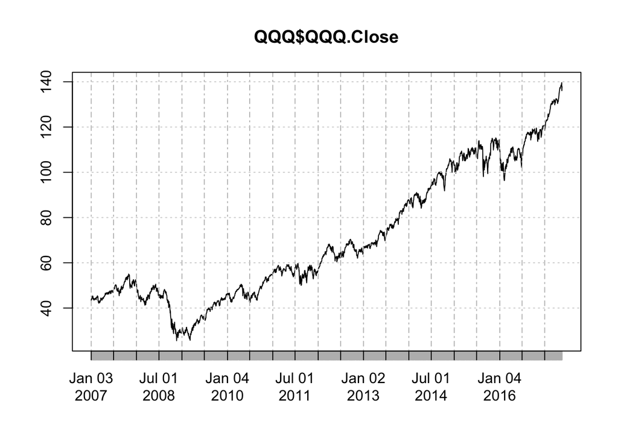

```r
plot(QQQ$QQQ.Close)
```

We’ll create a simple function to break down the data and average every price point by x amount of points prior to it. In this case we’ll use a 100 day smoothing period.

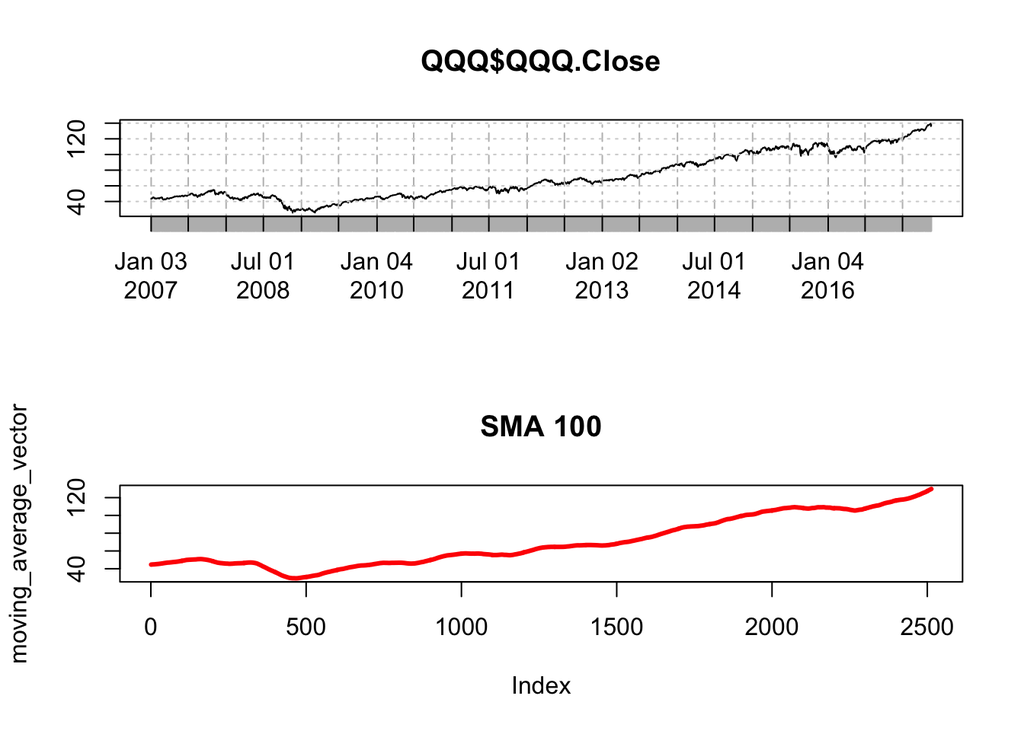

```r
period <- 100
price_vector <- QQQ$QQQ.Close
moving_average_vector <- c()
for (ind in seq((period+1),(length(price_vector))) ){
       moving_average_vector <- c(moving_average_vector, mean(price_vector[(ind-period):ind]))
}

par(mfrow=c(2,1))
plot(QQQ$QQQ.Close)
plot(moving_average_vector, type='l', col='red', lwd=3, main = paste('SMA', period))
```

```r
length(moving_average_vector)
```

```
## [1] 2513
```

The first plot is the raw **QQQ** daily closing prices and the second plot, is our smoothed version. Keep in mind that the first 100 days of price data can’t be used as that is the minimum data we need to create a 100 period average.

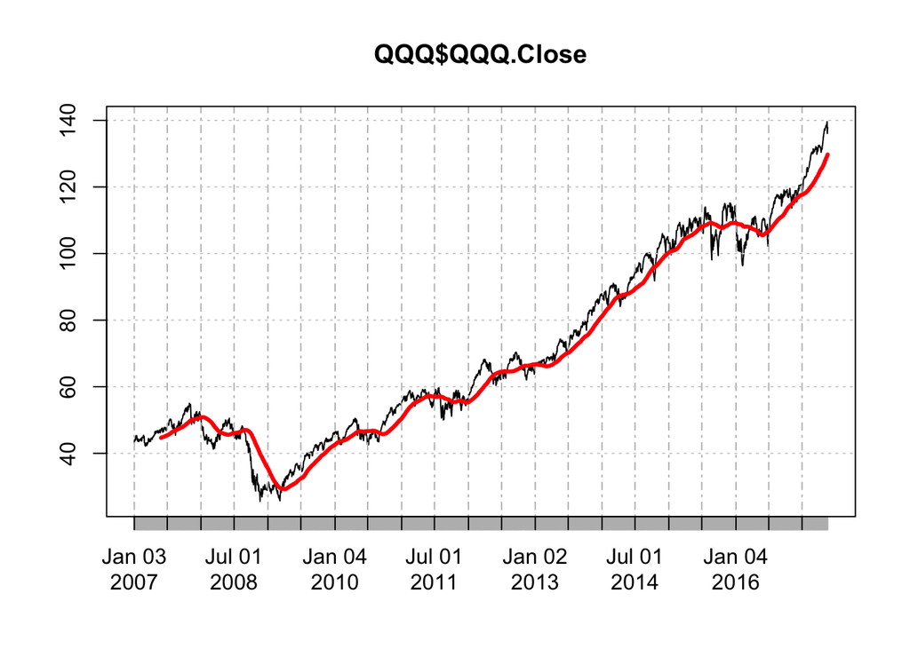

```r
period <- 100
price_vector <- QQQ$QQQ.Close
moving_average_vector <- c(rep(NA, period))
# moving_average_vector <- c(rep(as.numeric(QQQ$QQQ.Close[period]), period))
for (ind in seq((period+1),(length(price_vector))) ){
       moving_average_vector <- c(moving_average_vector, mean(price_vector[(ind-period):ind]))
}

# pass it back to our time series object
QQQ$QQQ.Close.SMA <- moving_average_vector

plot(QQQ$QQQ.Close)
lines(QQQ$QQQ.Close.SMA, type='l', col='red', lwd=3)
```

So, it is fairly simple and it will be even simpler going forward as we aren’t going to do any of this type of calculations again. Instead, we’ll let the **TTR** library do the math for for us.

**Overlaying a simple moving average (SMA) over a chart**

So, let’s do what we just did but with **TTR**:

```r
getSymbols(c('QQQ'), src='google')
```

```
## [1] "QQQ"
```

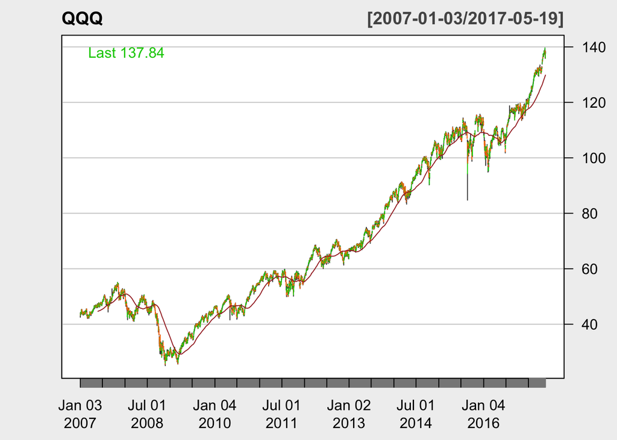

```r
chartSeries(QQQ, theme="white", TA="addSMA(100)")
```

A bit easier, right?

*TIP* To see the different indicators available in your package, type **add** and TAB in the console.

So, looking at the chart, how can we use this SMA? For starters, if the price is above the SMA, it is strong, if it is below, it is weak. In the trending market we’ve been seen since 2009, buying into the weak legs would have paid off (and in retrospect, just buying and holding would’ve been even better).

What about a less trending stock?

```r
library(quantmod)
getSymbols(c('EWP'), src='google')
```

```
## [1] "EWP"
```

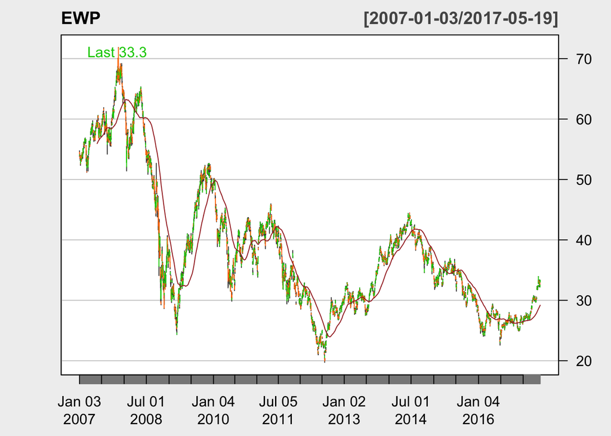

```r
chartSeries(EWP, theme="white", TA="addSMA(100)")
```

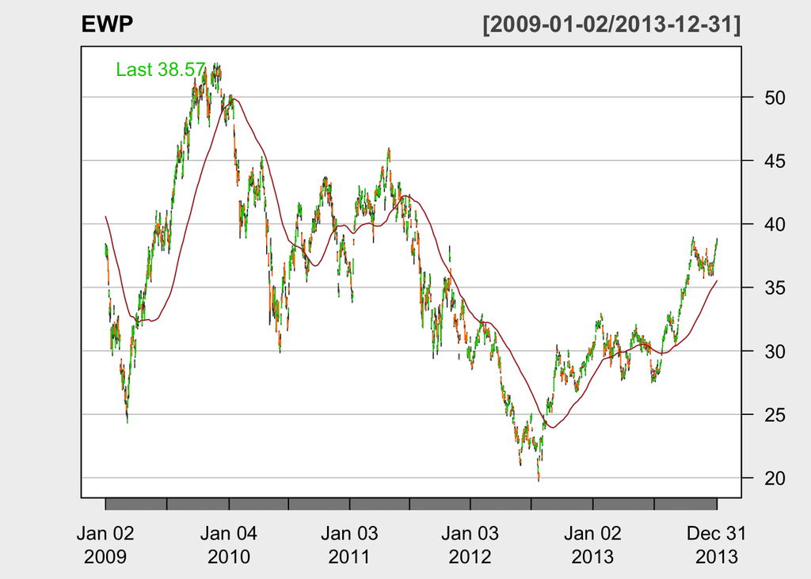

```r
chartSeries(EWP, theme="white", TA="addSMA(100)", subset='2009::2013')
```

One moving average does smooth the action but doesn’t really tell you what to do (more about this soon). Also, keep in mind that there are plenty of different types of moving averages used in technical analysis. One I like, is the [exponential moving average](https://en.wikipedia.org/wiki/Moving_average#Exponential_moving_average). This gives more weight to the recent numbers in the look-back period.